# SVMkNN

Marcela

16 de agosto de 2020

Vamos a considerar como ejemplo el conjunto de datos $\mathtt{sonar}$ de la libreria $\mathtt{mlbench}.$ El objetivo es poder disernir entre dos tipos de seniales, unas que rebotan contra un cilindro metalico y otras contra rocas cilindricas. Cada observacion del conjunto de datos conta de un conjunto de 60 parametros, todos ellos entre $0.0$ y $1.0.$ Cada coordenada reprecenta la energia en una banda de frecuencia especifica, integrada en un lapso de tiempo preestablecido. La etiquetas de las dos poblaciones son $\mathtt{R}$ para las rocas y $\mathtt{M}$ para los metales.

Hacemos un analisis exploratorio visual, utilizando boxplots.

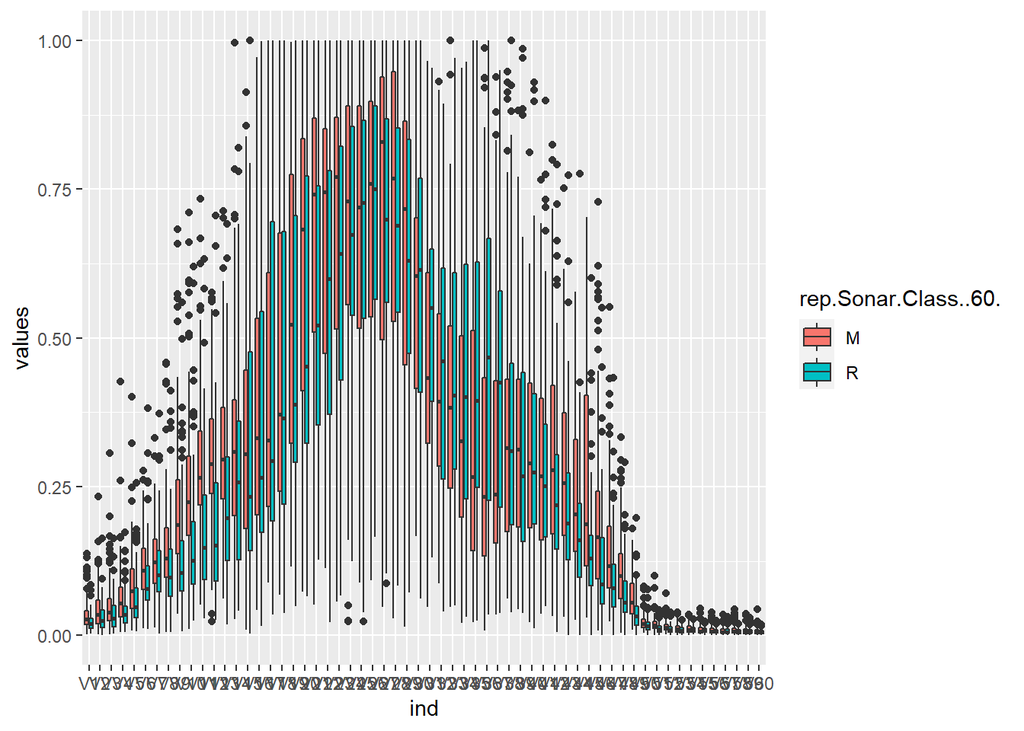

```r
data("Sonar")

sonar.df=data.frame(stack(Sonar[,1:60]),rep(Sonar$Class,60))
ggplot(sonar.df,aes(x=ind,y=values,fill=rep.Sonar.Class..60.))+geom_boxplot()
```

Separamos la muestra dejando el 75% como muestra de entrenamiento y el 25% restante como muestra de clasificacion.

```r
set.seed(324)
training_sample <- sample(c(TRUE, FALSE), nrow(Sonar), replace = T, prob = c(0.75,0.25))
train <- Sonar[training_sample, ]
test <- Sonar[!training_sample, ]
#Vamos a clasificar, tiene dos clases, primero cross validamos la
# el costo, utilizamos el clasificador lineal
tune.out <- tune(svm, Class~., data = train, kernel = "linear",
                 ranges = list(cost = c(0.001, 0.01, 0.1, 1, 5, 10, 100)))
bestmod <- tune.out$best.model
bestmod
```

```
##
## Call:
## best.tune(method = svm, train.x = Class ~ ., data = train, ranges = list(cost = c(0.001,
##     0.01, 0.1, 1, 5, 10, 100)), kernel = "linear")
##
##
## Parameters:
##    SVM-Type:  C-classification
##  SVM-Kernel:  linear
##        cost:  0.01
##
## Number of Support Vectors:  120
```

```r
Class.pred=predict(bestmod,test)
misclass =table(predict = Class.pred, truth = test$Class)

misclass
```

```
##        truth
## predict  M  R
##       M 24  2
##       R  2 19
```

Repetimos el proceso pero ahora utilizamos el nucleo radial.

```r
tune.out <- tune(svm, Class~., data = train, kernel = "radial",
                 ranges = list(cost = c(0.001, 0.01, 0.1, 1, 5, 10, 100),
                               gamma = c(0.5,1,2,3,4)))
bestmod <- tune.out$best.model
summary(bestmod)
```

```
##
## Call:
## best.tune(method = svm, train.x = Class ~ ., data = train, ranges = list(cost = c(0.001,
##     0.01, 0.1, 1, 5, 10, 100), gamma = c(0.5, 1, 2, 3, 4)), kernel = "radial")
##
##
## Parameters:
##    SVM-Type:  C-classification
##  SVM-Kernel:  radial
##        cost:  5
##
## Number of Support Vectors:  161
##
##  ( 76 85 )
##
##
## Number of Classes:  2
##
## Levels:
##  M R
```

```r
Class.pred=predict(bestmod,test)
misclass =table(predict = Class.pred, truth = test$Class)
misclass
```

```
##        truth
## predict  M  R
##       M 26 19
##       R  0  2
```

En este caso especifico la clasificacion resulta ser mucho peor, hay un 40% de los datos mal clasificados.

Pasamos ahora a la clasificacion por vecinos mas cercanos. En este caso, probaremos primero sin estandarizar los datos y luego estandarizandolos. En este caso al estar todos en la misma escala no es necesario estandarizar la escala, sin embargo al hacer los boxplots vemos que hay diferencias importantes en algunas frecuencias. El numero de vecinos mas cercanos los cross validaremos con 5-fold-cross validation, seleccionando $k=1$. Luego, clasificaremos la muestra de testeo.

```r
library(caret)
trControl <- trainControl(method  = "cv", number  = 5)

fit <- train(Class ~ .,
             method     = "knn",
             tuneGrid   = expand.grid(k = 1:10),
             trControl  = trControl,
             metric     = "Accuracy",
             data       = train)
fit
```

```
## k-Nearest Neighbors
##
## 161 samples
##  60 predictor
##   2 classes: 'M', 'R'
##
## No pre-processing
## Resampling: Cross-Validated (5 fold)
## Summary of sample sizes: 129, 129, 128, 129, 129
## Resampling results across tuning parameters:
##
##   k   Accuracy   Kappa
##    1  0.7892045  0.5748314
##    2  0.7524621  0.4992660
##    3  0.7714015  0.5353848
##    4  0.7587121  0.5117507
##    5  0.7210227  0.4330352
##    6  0.7090909  0.4109415
##    7  0.6714015  0.3341436
##    8  0.6840909  0.3620660
##    9  0.6467803  0.2833383
##   10  0.6342803  0.2579655
##
## Accuracy was used to select the optimal model using the largest value.
## The final value used for the model was k = 1.
```

```r
# la mejor accuracy es para k=1
library(class)
pred.knn=knn(train[,1:60],test[,1:60],cl=train$Class,k=fit$bestTune)

conf.matrix <- table(test$Class, pred.knn)
rownames(conf.matrix) <- paste("Actual", rownames(conf.matrix), sep = ":")
colnames(conf.matrix) <- paste("Pred", colnames(conf.matrix), sep = ":")
print(conf.matrix)
```

```
##           pred.knn
##            Pred:M Pred:R
##   Actual:M     25      1
##   Actual:R      5     16
```

En este caso, tenemos 6 observaciones mal clasificadas, es decir el 12.77% de la muestra de validacion.

Repetimos estandarizando los datos para que tengan media cero y varianza uno.

```r
train.st=scale(train[,1:60])
test.st=scale(test[,1:60])

train.st.df=data.frame(train.st,train$Class)
trControl <- trainControl(method  = "cv", number  = 5)

fit <- train(train.Class ~ .,
             method     = "knn",
             tuneGrid   = expand.grid(k = 1:10),
             trControl  = trControl,
             metric     = "Accuracy",
             data       = train.st.df)
fit
```

```
## k-Nearest Neighbors
##
## 161 samples
##  60 predictor
##   2 classes: 'M', 'R'
##
## No pre-processing
## Resampling: Cross-Validated (5 fold)
## Summary of sample sizes: 129, 129, 129, 129, 128
## Resampling results across tuning parameters:
##
##   k   Accuracy   Kappa
##    1  0.8318182  0.6605603
##    2  0.8011364  0.5983164
##    3  0.8195076  0.6341299
##    4  0.7636364  0.5189517
##    5  0.7636364  0.5188936
##    6  0.7386364  0.4676896
##    7  0.7321970  0.4569489
##    8  0.7071970  0.4049297
##    9  0.7013258  0.3927293
##   10  0.7013258  0.3913187
##
## Accuracy was used to select the optimal model using the largest value.
## The final value used for the model was k = 1.
```

```r
# la mejor accuracy es para k=1
pred.knn=knn(train.st[,1:60],test.st[,1:60],cl=train$Class,k=fit$bestTune)

conf.matrix <- table(test$Class, pred.knn)
rownames(conf.matrix) <- paste("Actual", rownames(conf.matrix), sep = ":")
colnames(conf.matrix) <- paste("Pred", colnames(conf.matrix), sep = ":")
print(conf.matrix)
```

```
##           pred.knn
##            Pred:M Pred:R
##   Actual:M     26      0
##   Actual:R      2     19
```